# Recursos 11

8 actividades; combustible con suministro de 70 l/semana

# Enunciado

Considere el proyecto cuyo cuadro de prelaciones y duraciones (semanas) se adjunta. Cada actividad consume cada semana la cantidad de combustible indicada (litros/semana). El suministrador entrega como máximo 70 litros por semana.

1. Dibuje el diagrama de consumo semanal con las actividades en su inicio más temprano. ¿En qué semanas se supera el suministro?

2. Si no se puede almacenar combustible de una semana para la siguiente, reprograme el proyecto para respetar el suministro (algoritmo de asignación). ¿Cuánto se alarga?

3. Si en cambio se dispone de un depósito donde guardar lo no consumido, la restricción pasa a ser acumulada: el consumo acumulado hasta cada semana no puede superar el suministro acumulado. Compruebe si la programación original la cumple.

4. Compare ambas situaciones. ¿Qué tipo de recurso son los operarios de los ejercicios anteriores?

Tabla 1: Cuadro de datos del enunciado

| activity | predecessor | duration | resources |
| --- | --- | --- | --- |
| A | --- | 8 | 20 |
| B | --- | 4 | 50 |
| C | B | 1 | 20 |
| D | A | 3 | 40 |
| E | B,D | 6 | 10 |
| F | C | 5 | 40 |
| G | D,F | 3 | 50 |
| H | E,G | 2 | 20 |

El proyecto corresponde al lanzamiento de una aplicación móvil; las actividades son las siguientes (las duraciones del cuadro están en semanas).

Tabla 2: Descripción de las actividades

|  | Descripción |
| --- | --- |
| A | Estudio de requisitos |
| B | Diseño de la arquitectura |
| C | Diseño de interfaz y prototipo |
| D | Base de datos y modelo |
| E | API del servidor |
| F | Pantallas principales |
| G | Módulo de pagos |
| H | Notificaciones y sincronización |

# Resolución

## Apartado 1

1. Dibuje el diagrama de consumo semanal con las actividades en su inicio más temprano. ¿En qué semanas se supera el suministro?

Cálculo de los tiempos mínimos y máximos de los nodos del grafo Roy paso a paso. El primer paso muestra el grafo resuelto; a partir del siguiente se calcula desde el principio (avance con los botones):

[figure not shown]

paso 0 de 22

[figure not shown]

Figura 1: Grafo Roy con tiempos y camino crítico

Tabla 3: Calendario: fechas y holgura total de cada actividad

[figure not shown]

ninguna celda (0 de 64)

[figure not shown]

Haz clic en un número de la tabla para ver cómo se calcula.

👆 **Interactivo:** haz clic en cualquier celda de la tabla para ver cómo se calcula (otro clic la deselecciona), o usa los botones y las flechas del teclado.

| Actividad | Duración | Inicio más temprano | Fin más temprano | Inicio más tardío | Fin más tardío | H total | H libre | H independiente |
| --- | --- | --- | --- | --- | --- | --- | --- | --- |
| A | 8 | 0 | 8 | 0 | 8 | 0 | 0 | 0 |
| B | 4 | 0 | 4 | 4 | 8 | 4 | 0 | 0 |
| C | 1 | 4 | 5 | 8 | 9 | 4 | 0 | 0 |
| D | 3 | 8 | 11 | 8 | 11 | 0 | 0 | 0 |
| E | 6 | 11 | 17 | 11 | 17 | 0 | 0 | 0 |
| F | 5 | 5 | 10 | 9 | 14 | 4 | 1 | 0 |
| G | 3 | 11 | 14 | 14 | 17 | 3 | 3 | 0 |
| H | 2 | 17 | 19 | 17 | 19 | 0 | 0 | 0 |

En el Gantt cada actividad ocupa sus semanas desde su inicio más temprano con su consumo semanal; la fila *Total* es el consumo de cada semana.

[figure not shown]

Figura 2: Diagrama de Gantt con el consumo semanal

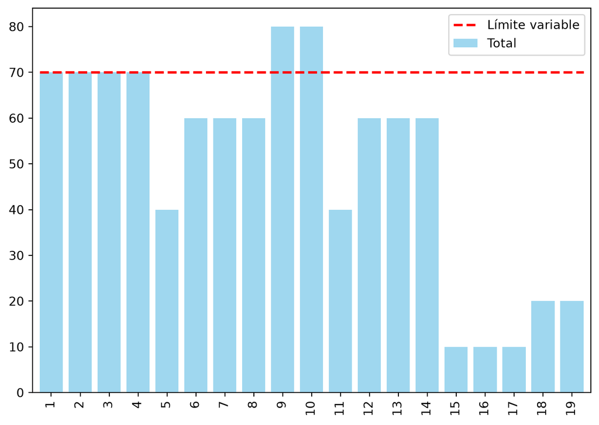

Figura 3: Consumo semanal frente al suministro

**Respuesta:** se supera el suministro en las semanas 9 y 10 (semana 9: 80 > 70; semana 10: 80 > 70); el consumo máximo es de 80 litros.

## Apartado 2

2. Si no se puede almacenar combustible de una semana para la siguiente, reprograme el proyecto para respetar el suministro (algoritmo de asignación). ¿Cuánto se alarga?

Sin depósito, el suministro es un límite semanal como el de los operarios, y se aplica el algoritmo de asignación.

Regla del algoritmo: en cada semana se toman las actividades que el calendario vigente sitúa en ella y se ordenan así: primero las ya empezadas (no se interrumpen); después, menor holgura total (recalculada tras los aplazamientos anteriores) y, a igualdad, menor duración. Se admiten en ese orden mientras la suma de recursos no supere el límite; las que no caben se aplazan una semana (y con ellas sus sucesoras, si no tienen holgura). En la traza, *Total* es la demanda de esa semana antes de aplazar.

Traza semana a semana:

Periodo: 1.

Periodo: 1. Total: 70. Se programan: [‘B’, ‘A’]

Periodo: 2.

Periodo: 2. Total: 70. Se programan: [‘B’, ‘A’]

Periodo: 3.

Periodo: 3. Total: 70. Se programan: [‘B’, ‘A’]

Periodo: 4.

Periodo: 4. Total: 70. Se programan: [‘B’, ‘A’]

Periodo: 5.

Periodo: 5. Total: 40. Se programan: [‘C’, ‘A’]

Periodo: 6.

Periodo: 6. Total: 60. Se programan: [‘F’, ‘A’]

Periodo: 7.

Periodo: 7. Total: 60. Se programan: [‘F’, ‘A’]

Periodo: 8.

Periodo: 8. Total: 60. Se programan: [‘F’, ‘A’]

Periodo: 9.

Periodo: 9. Total: 80. Se programan: [‘F’]

Periodo: 9. Se desplazan: [‘D’]

Periodo: 10.

Periodo: 10. Total: 80. Se programan: [‘F’]

Periodo: 10. Se desplazan: [‘D’]

Periodo: 11.

Periodo: 11. Total: 40. Se programan: [‘D’]

Periodo: 12.

Periodo: 12. Total: 40. Se programan: [‘D’]

Periodo: 13.

Periodo: 13. Total: 40. Se programan: [‘D’]

Periodo: 14.

Periodo: 14. Total: 60. Se programan: [‘E’, ‘G’]

Periodo: 15.

Periodo: 15. Total: 60. Se programan: [‘E’, ‘G’]

Periodo: 16.

Periodo: 16. Total: 60. Se programan: [‘E’, ‘G’]

Periodo: 17.

Periodo: 17. Total: 10. Se programan: [‘E’]

Periodo: 18.

Periodo: 18. Total: 10. Se programan: [‘E’]

Periodo: 19.

Periodo: 19. Total: 10. Se programan: [‘E’]

Periodo: 20.

Periodo: 20. Total: 20. Se programan: [‘H’]

Periodo: 21.

Periodo: 21. Total: 20. Se programan: [‘H’]

Tabla 4: Semanas con conflicto: orden de prioridad, qué entra y qué se aplaza

| semana | límite | demanda | orden de prioridad (holgura, duración, recurso) | entran | se aplazan una semana (no caben) |
| --- | --- | --- | --- | --- | --- |
| 9 | 70 | 80 | F (en curso, 40) › D (H=0, d=3, 40) | F | D: 40 + 40 = 80 > 70 |
| 10 | 70 | 80 | F (en curso, 40) › D (H=0, d=3, 40) | F | D: 40 + 40 = 80 > 70 |

[figure not shown]

Figura 4: Diagrama de Gantt tras la asignación

**Respuesta:** sin almacenamiento el proyecto pasa de 19 a 21 semanas (se alarga 2 semanas); esperas introducidas: D 2 semanas.

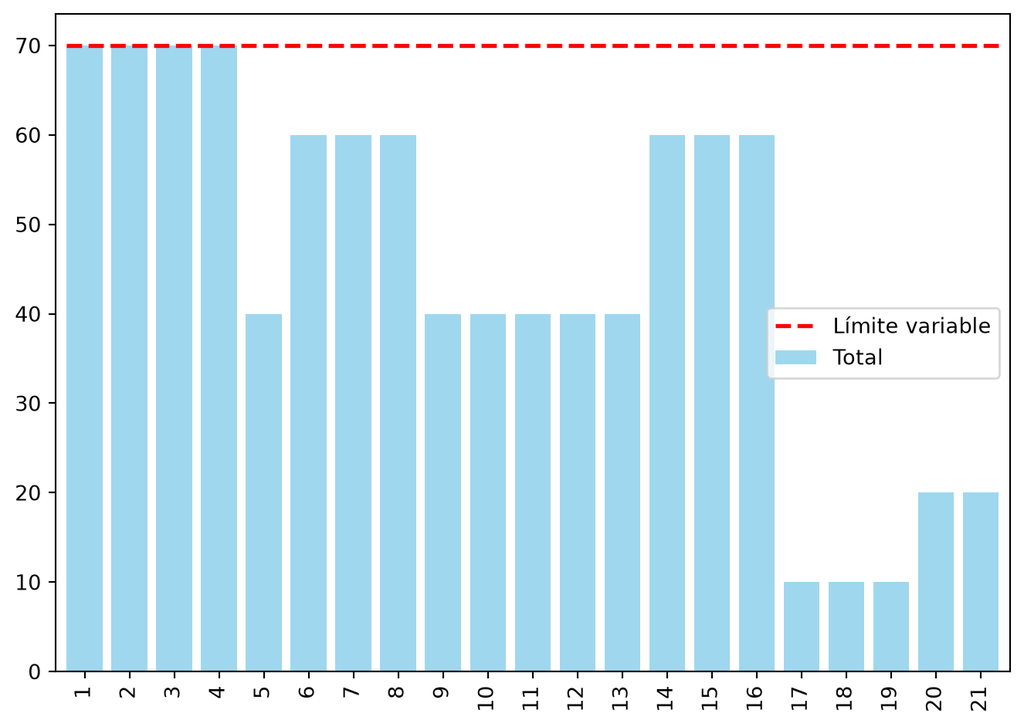

Figura 5: Consumo semanal tras la asignación frente al suministro

## Apartado 3

3. Si en cambio se dispone de un depósito donde guardar lo no consumido, la restricción pasa a ser acumulada: el consumo acumulado hasta cada semana no puede superar el suministro acumulado. Compruebe si la programación original la cumple.

Con depósito, lo no consumido una semana queda disponible para las siguientes: basta con que el consumo acumulado hasta cada semana no supere lo entregado hasta entonces ($\sum_{s \le t} c_s \le t \cdot S$). La fila *margen* es la diferencia, es decir, lo que hay en el depósito al final de cada semana.

|  | 1 | 2 | 3 | 4 | 5 | 6 | 7 | 8 | 9 | 10 | 11 | 12 | 13 | 14 | 15 | 16 | 17 | 18 | 19 |
| --- | --- | --- | --- | --- | --- | --- | --- | --- | --- | --- | --- | --- | --- | --- | --- | --- | --- | --- | --- |
| consumo acumulado | 70 | 140 | 210 | 280 | 320 | 380 | 440 | 500 | 580 | 660 | 700 | 760 | 820 | 880 | 890 | 900 | 910 | 930 | 950 |
| suministro acumulado | 70 | 140 | 210 | 280 | 350 | 420 | 490 | 560 | 630 | 700 | 770 | 840 | 910 | 980 | 1050 | 1120 | 1190 | 1260 | 1330 |
| margen | 0 | 0 | 0 | 0 | 30 | 40 | 50 | 60 | 50 | 40 | 70 | 80 | 90 | 100 | 160 | 220 | 280 | 330 | 380 |
| cumple | sí | sí | sí | sí | sí | sí | sí | sí | sí | sí | sí | sí | sí | sí | sí | sí | sí | sí | sí |

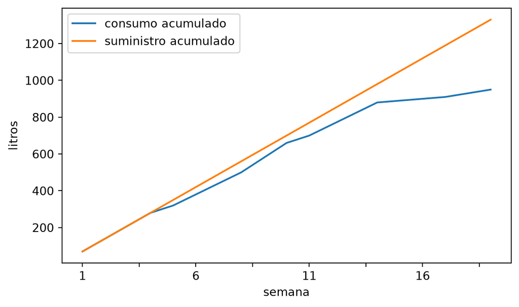

Figura 6: Consumo y suministro acumulados

**Respuesta:** con depósito la programación original es viable: en todas las semanas lo entregado cubre lo consumido. La semana más ajustada es la 1: 70 − 70 = 0 litros de margen. El depósito absorbe los picos con lo sobrante de las semanas de menos consumo.

## Apartado 4

4. Compare ambas situaciones. ¿Qué tipo de recurso son los operarios de los ejercicios anteriores?

Sin depósito el proyecto dura 21 semanas; con depósito, 19 (la programación original es viable). Un recurso no almacenable (mano de obra, maquinaria, un suministro que no cabe en depósito) impone una restricción semana a semana; uno almacenable impone una restricción acumulada, mucho menos exigente. **Respuesta:** los operarios son recursos no almacenables (renovables): las horas de un operario que no se usan esta semana no se guardan para la siguiente. Por eso se tratan con asignación, y los consumibles almacenables con balances acumulados (y un depósito con capacidad para el mayor margen acumulado que haya que guardar).